# Differential Expression Analysis for hepatic diseases

2023-12-13

## Differential Expression analysis for hepatic diseases

# Introduction

Differential expression analyses help to determine if protein levels are different between two conditions. Thus, the first step is to define groups. The PCA and the boxplots from individual peptides showed two potential groups that could render useful results from a DEA when compared to all the rest. On the one hand, **infectious diseases** show several proteins whose levels differ from those of all the other diseases. This pattern is followed by pyelonephritis, penumonia, sepsis and necrotizing soft tissue infection. However, it is not followed by viral hepatitis-related cirrhosis, which was also classified as an infectious disease in this data set. Instead, viral hepatitis-related cirrhosis would be part of the second promising group: **hepatic diseases**. This group would be made up of four diseases which were assigned different classes in this data set: hepatocellular cancer, fatty liver disease, chronic liver disease and the aforementioned viral hepatitis-related cirrhosis.

# T-tests with corrections

A t-test will be performed to statistically compare the means of the all the targeted proteins between the two defined groups with the aim of determining whether any differences are likely to stem from biological variation instead of happening by chance. This test statistic would follow a Student’s t-distribution under the null hypothesis that there is no difference. Therefore, it is a parametric test. However, since the hypothesis is simultaneously being tested multiple times, the significance threshold needs to be made stricter to avoid getting false positive. The reason behind it being that it becomes increasingly likely to mistakenly reject a null hypothesis as the number of tests increases. Here, over 200 tests are being performed simultaneously, for which a p-value threshold of 0.05 could mean more than 10 false positives. Thus, two commonly used correction methods will be tested: FDR-based and Bonferroni.

The false discovery rate represents the percentage (or rate) of significant features which are actually null (Storey & Tibshirani, 2003). This method uses the q-value, which estimates the pFDR by rejecting the null hypothesis for a result which as that or a smaller q-value. In other words, it is the proportion of false positives in all positives. A q-value of 0.05 means that 5% of the features belonging to the null hypothesis will be incorrectly deemed significant. Similarly to the p value, the q value gives each feature its own individual measure of significance.

Similarly, the Bonferroni correction is meant to counter the increased probability of running into a Type I error by setting a new a significance level *alpha/m*, which means basically dividing the level of significance by the number of tested hypotheses. Here, the “bonferroni” method in p.adjust performs multiplies each p value by the number of tested hypothesis (208) and thus returns the Bonferroni-currected values. Bonferroni is a especially stringent method which can really reduce the number of false positives for a large *m* (Aggarwal & Yadav, 2016). However, the trade-off is the increase of false negatives.

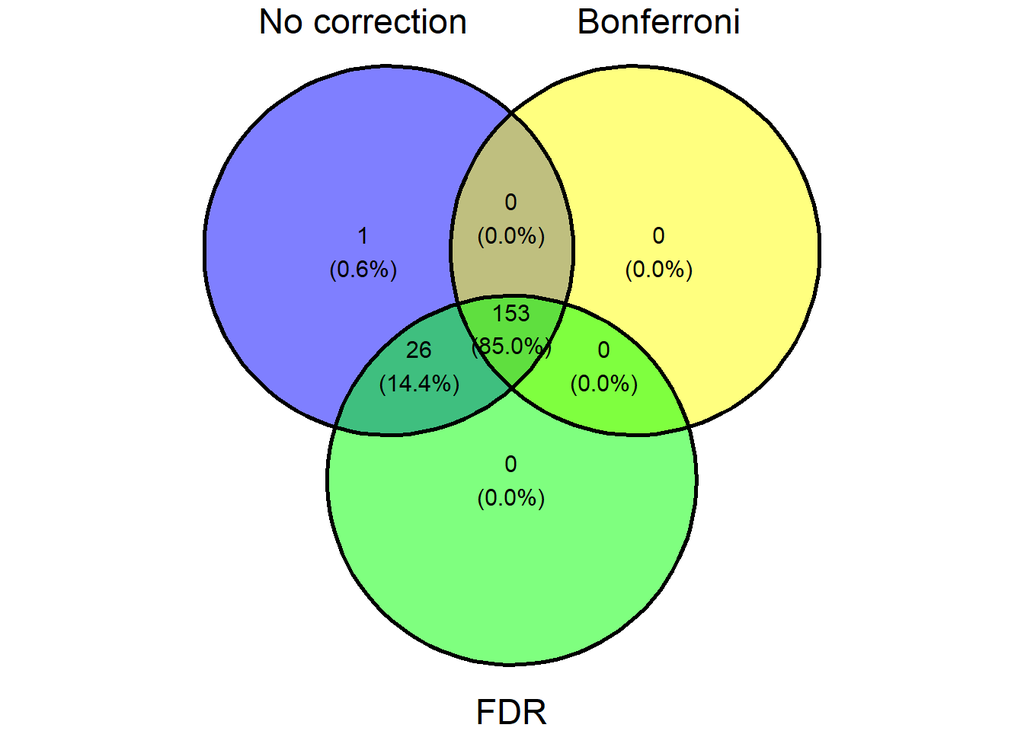

**No p-value correction**: 180

**FDR (Benjamini-Hochberg) correction**: 179

—- Up in hepatic diseases: 18

—- Down in hepatic diseases: 161

**Bonferroni correction**: 153

—- Up in hepatic diseases: 8

—- Down in hepatic diseases: 145

# Volcano plots

The volcano plot is a visual tool to represent the results from the t-test. The p-value (-log10 transformed) is shown on the y-axis and the log2-fold change on the x-axis. Beyond applying multiple hypotheses testing corrections, applying a fold change cut-off can also reduce the FDR while tending to keep the true positives (Pascovici et al., 2016). For visualization purposes, the x-axis is going to be limited to (-7,7) fold-change. This excludes 16 peptides, whose names can be found in the list underneath the plot.

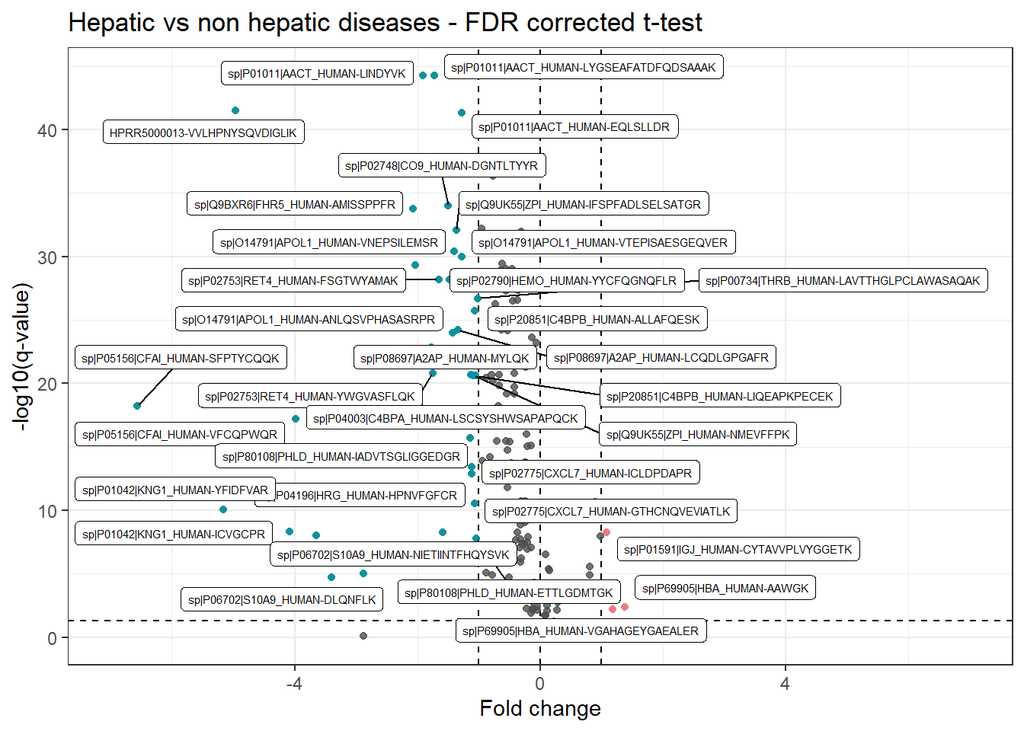

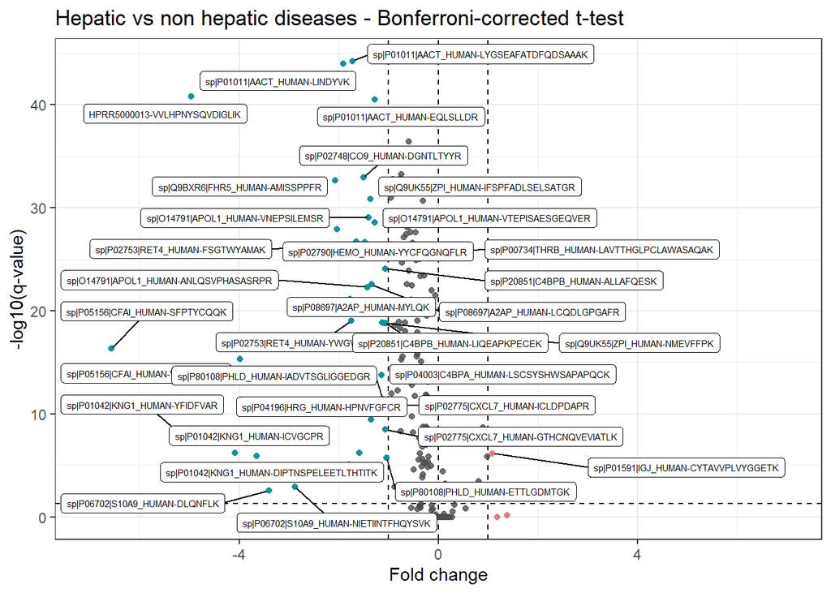

```
##                                                       FC        adj.p
## HPRR5000013-YVMLPVADQDQCIR                   -181.730764 4.564282e-44
## HPRR5000013-VGYVSGWGR                        -156.306496 7.426046e-43
## sp|P02647|APOA1_HUMAN-VSFLSALEEYTK            -10.649654 1.014955e-34
## sp|P02647|APOA1_HUMAN-QGLLPVLESFK              -9.339149 3.621266e-34
## HPRR5000023-SDVVYTDWK                         -11.646827 7.967749e-33
## sp|P02766|TTHY_HUMAN-GSPAINVAVHVFR            -13.256579 4.521058e-32
## sp|P02766|TTHY_HUMAN-AADDTWEPFASGK            -15.125786 3.018822e-31
## sp|P02652|APOA2_HUMAN-EPCVESLVSQYFQTVTDYGK    -11.551307 2.209986e-23
## sp|P02766|TTHY_HUMAN-ALGISPFHEHAEVVFTANDSGPR  -10.783756 2.413444e-19
## sp|P01009|A1AT_HUMAN-SVLGQLGITK               -24.675414 9.678951e-15
## sp|P01009|A1AT_HUMAN-LSITGTYDLK               -24.052368 2.598933e-14
## sp|P01009|A1AT_HUMAN-VFSNGADLSGVTEEAPLK       -27.281983 6.835650e-14
## sp|P01009|A1AT_HUMAN-GTEAAGAMFLEAIPMSIPPEVK   -22.836163 2.143618e-13
## sp|P02749|APOH_HUMAN-FICPLTGLWPINTLK         -259.904201 2.333801e-11
## sp|P01009|A1AT_HUMAN-AVLTIDEK                 -20.564082 2.918992e-09
## sp|P02649|APOE_HUMAN-LQAEAFQAR                -19.013005 5.039555e-03
##                                                bonferroni
## HPRR5000013-YVMLPVADQDQCIR                   1.369285e-43
## HPRR5000013-VGYVSGWGR                        2.970419e-42
## sp|P02647|APOA1_HUMAN-VSFLSALEEYTK           1.066474e-33
## sp|P02647|APOA1_HUMAN-QGLLPVLESFK            5.431899e-33
## HPRR5000023-SDVVYTDWK                        1.354517e-31
## sp|P02766|TTHY_HUMAN-GSPAINVAVHVFR           9.042116e-31
## sp|P02766|TTHY_HUMAN-AADDTWEPFASGK           6.339527e-30
## sp|P02652|APOA2_HUMAN-EPCVESLVSQYFQTVTDYGK   1.149193e-21
## sp|P02766|TTHY_HUMAN-ALGISPFHEHAEVVFTANDSGPR 1.761814e-17
## sp|P01009|A1AT_HUMAN-SVLGQLGITK              8.807845e-13
## sp|P01009|A1AT_HUMAN-LSITGTYDLK              2.494976e-12
## sp|P01009|A1AT_HUMAN-VFSNGADLSGVTEEAPLK      6.835650e-12
## sp|P01009|A1AT_HUMAN-GTEAAGAMFLEAIPMSIPPEVK  2.186490e-11
## sp|P02749|APOH_HUMAN-FICPLTGLWPINTLK         2.590519e-09
## sp|P01009|A1AT_HUMAN-AVLTIDEK                3.473600e-07
## sp|P02649|APOE_HUMAN-LQAEAFQAR               8.516848e-01
```

The clustering and principal component analyses can now be repeated based only on the differentially expressed proteins to visualize how well they can separate the samples belonging to hepatic and non-hepatic diseases from each other. The first heatmap shows all the differentially expressed peptides that reached a significant FDR corrected value, while the second one only shows the peptide with the highest mean per protein. Having added a column to classify hepatic and non-hepatic diseases, it has now become aparent that the hepatic diseases do form several clusters in which the significant downregulation of many proteins stands out.

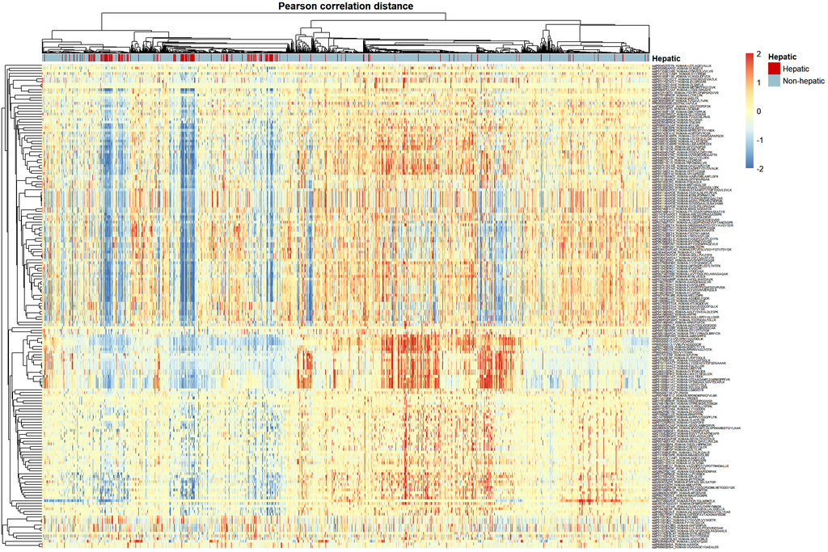

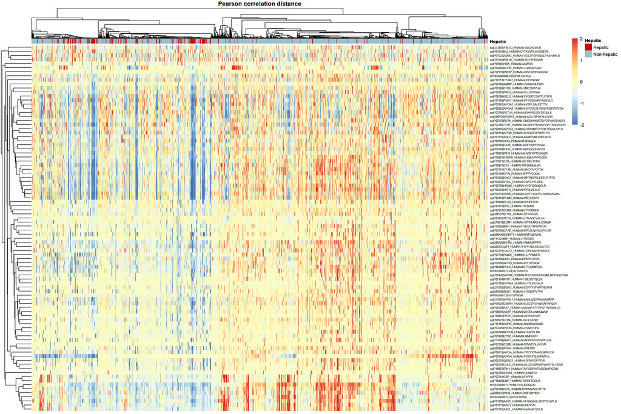

Regarding the PCA, the variance explained by each the first 3 PCs is very similar and the data points belonging to the hepatic diseases occupy very similar positions to those seen in the PCA plot which considered all peptides. The group formed by the hepatic diseases is relatively well segretated into the bottom left corner, indicating that both PC1 and PC2 have a strong effect on these samples. In the case of PC3, which did not seem to provide much more information initially, the samples belonging to hepatic diseases seem to show a tendency to go towards the bottom left corner again. This better separates them from the group of infectious diseases. All of the features in the PCs from this analysis were also in the same PC for the initial PCA.

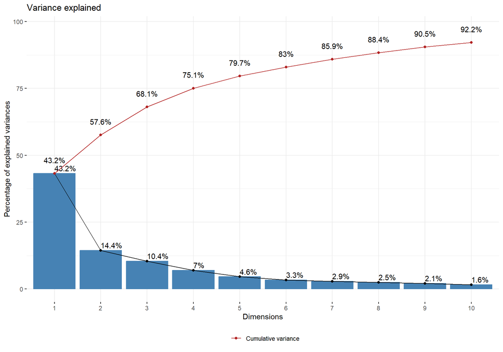

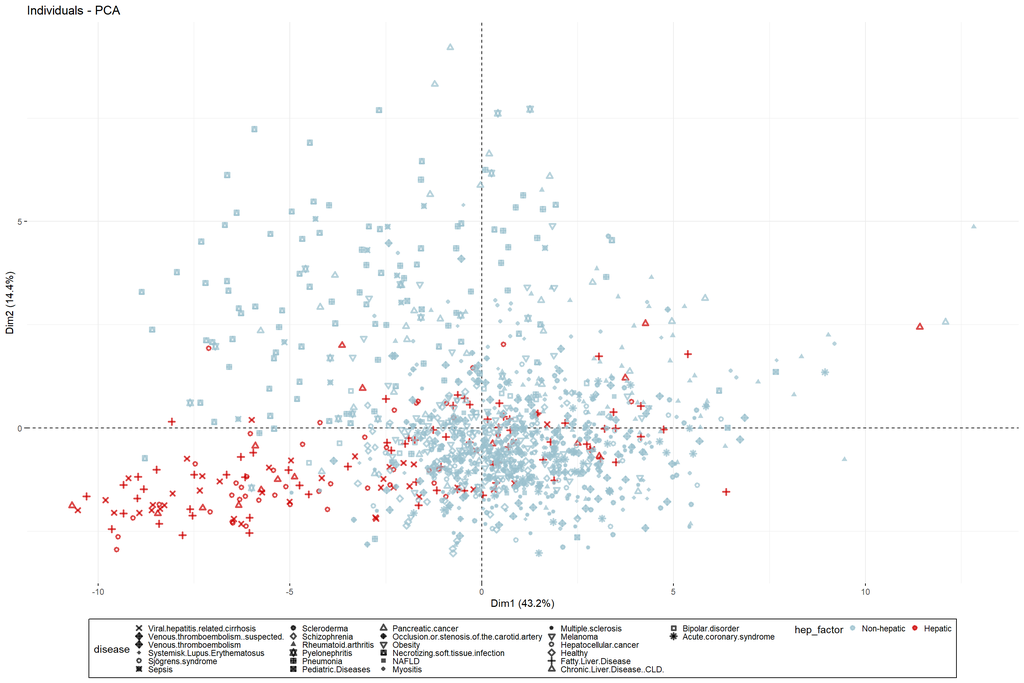

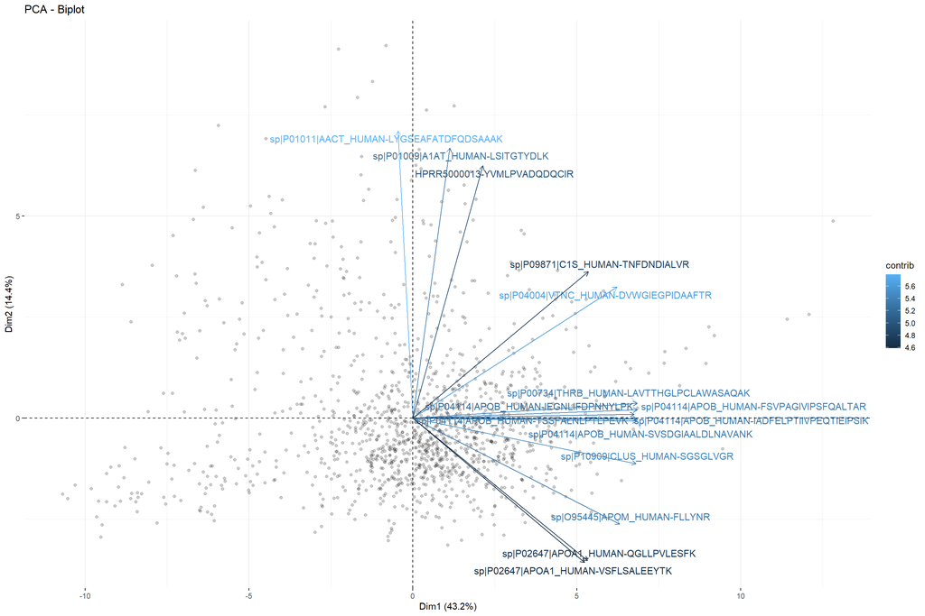

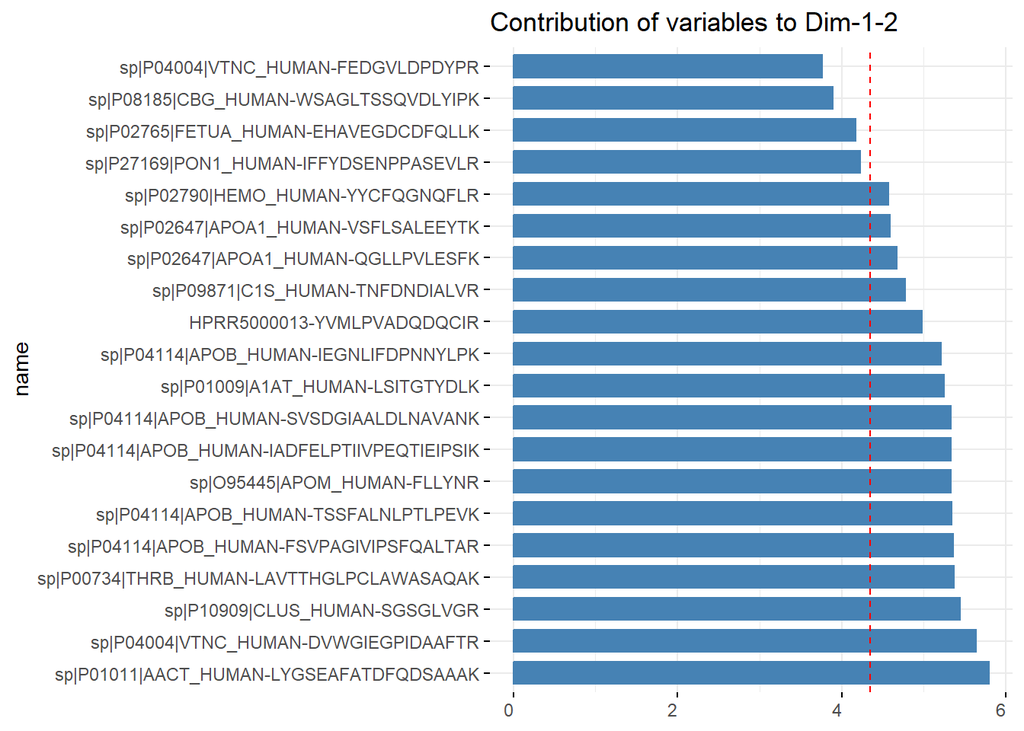

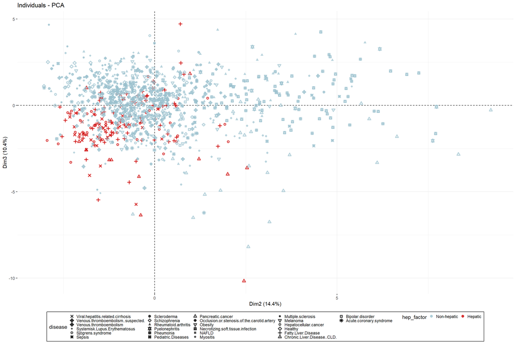

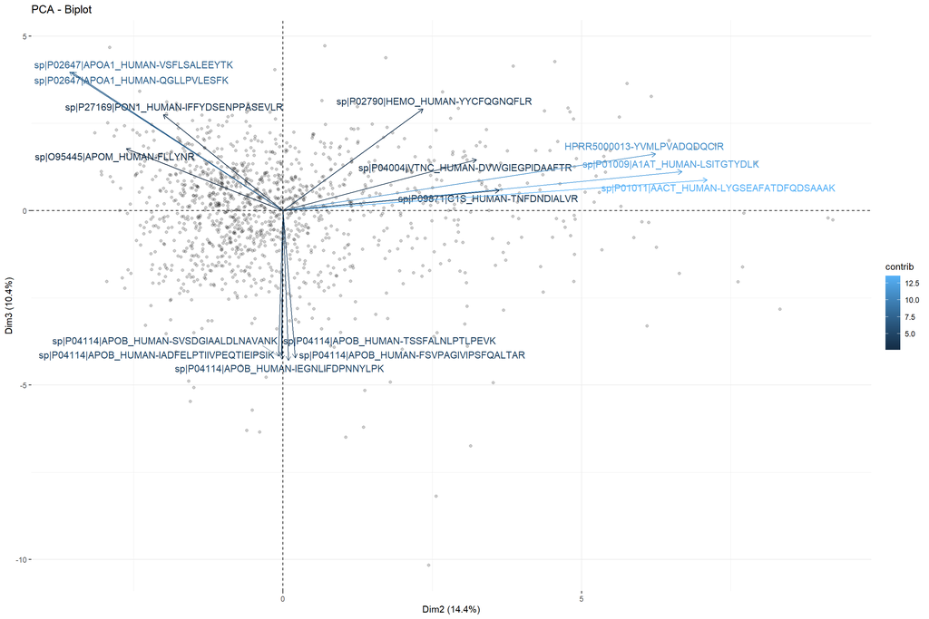

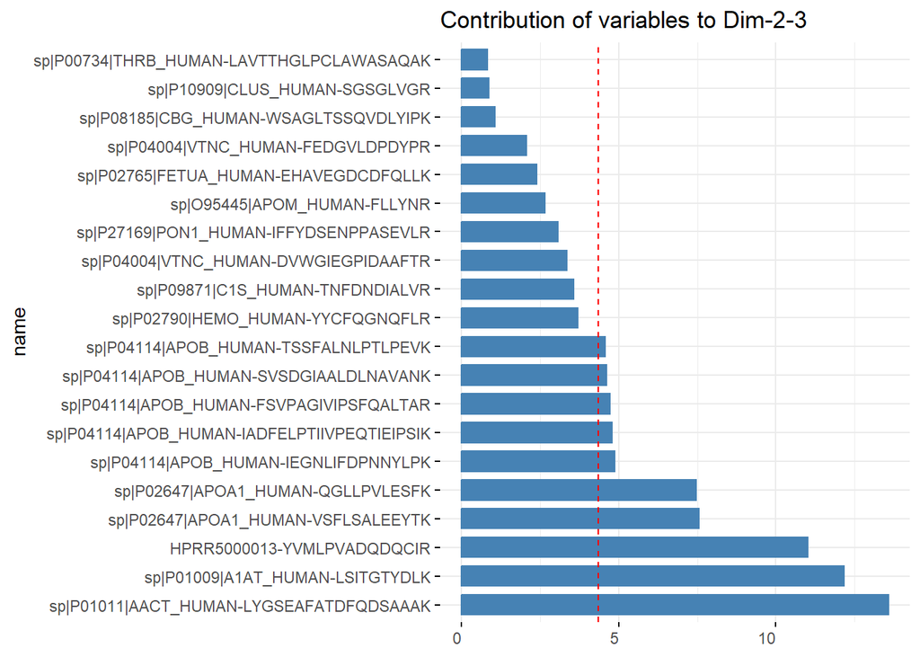

**List of most influential variables and their loading:**

```
## $Variable
##  [1] "sp|P04114|APOB_HUMAN-FSVPAGIVIPSFQALTAR"
##  [2] "sp|P00734|THRB_HUMAN-LAVTTHGLPCLAWASAQAK"
##  [3] "sp|P04114|APOB_HUMAN-TSSFALNLPTLPEVK"
##  [4] "sp|P04114|APOB_HUMAN-IADFELPTIIVPEQTIEIPSIK"
##  [5] "sp|P04114|APOB_HUMAN-SVSDGIAALDLNAVANK"
##  [6] "sp|P10909|CLUS_HUMAN-SGSGLVGR"
##  [7] "sp|P04114|APOB_HUMAN-IEGNLIFDPNNYLPK"
##  [8] "sp|O95445|APOM_HUMAN-FLLYNR"
##  [9] "sp|P04004|VTNC_HUMAN-DVWGIEGPIDAAFTR"
## [10] "sp|P02790|HEMO_HUMAN-YYCFQGNQFLR"
## [11] "sp|P08185|CBG_HUMAN-WSAGLTSSQVDLYIPK"
## [12] "sp|P27169|PON1_HUMAN-IFFYDSENPPASEVLR"
## [13] "sp|P09871|C1S_HUMAN-TNFDNDIALVR"
## [14] "sp|P02647|APOA1_HUMAN-QGLLPVLESFK"
```

[output cut: 59 more lines]

**Shared peptides with the full PCA (all):**

```
##  [1] "sp|P04114|APOB_HUMAN-FSVPAGIVIPSFQALTAR"
##  [2] "sp|P00734|THRB_HUMAN-LAVTTHGLPCLAWASAQAK"
##  [3] "sp|P04114|APOB_HUMAN-TSSFALNLPTLPEVK"
##  [4] "sp|P04114|APOB_HUMAN-IADFELPTIIVPEQTIEIPSIK"
##  [5] "sp|P04114|APOB_HUMAN-SVSDGIAALDLNAVANK"
##  [6] "sp|P10909|CLUS_HUMAN-SGSGLVGR"
##  [7] "sp|P04114|APOB_HUMAN-IEGNLIFDPNNYLPK"
##  [8] "sp|O95445|APOM_HUMAN-FLLYNR"
##  [9] "sp|P04004|VTNC_HUMAN-DVWGIEGPIDAAFTR"
## [10] "sp|P02790|HEMO_HUMAN-YYCFQGNQFLR"
## [11] "sp|P08185|CBG_HUMAN-WSAGLTSSQVDLYIPK"
## [12] "sp|P27169|PON1_HUMAN-IFFYDSENPPASEVLR"
## [13] "sp|P09871|C1S_HUMAN-TNFDNDIALVR"
## [14] "sp|P02647|APOA1_HUMAN-QGLLPVLESFK"
## [15] "sp|P02765|FETUA_HUMAN-EHAVEGDCDFQLLK"
```

[output cut: 54 more lines]

# References

Aggarwal, S., & Yadav, A. K. (2016). False discovery rate estimation in proteomics. Statistical Analysis in Proteomics, 119-128.

Pascovici, D., Handler, D. C., Wu, J. X., & Haynes, P. A. (2016). Multiple testing corrections in quantitative proteomics: A useful but blunt tool. *Proteomics, 16*(18), 2448-2453.

Storey, J. D., & Tibshirani, R. (2003). Statistical significance for genomewide studies. *Proceedings of the National Academy of Sciences, 100*(16), 9440-9445.